# Washington State Medicaid Dental Expenses

Brian High

05/21/2015

This work is licensed under a [Creative Commons Attribution-ShareAlike 4.0 International License](http://creativecommons.org/licenses/by-sa/4.0/).

## Geographical Heatmap

This serves as an example of making a geographical “heatmap” (choropleth). In particular, a Washington State map with counties colored by the value of a variable. We will use the average annual expenses of Medicaid dental care per Medicaid user averaged by county. This project was inspired by a [related example](https://blogs.baylor.edu/alex_beaujean/2013/06/28/creating-a-map-in-r/).

## Data Sources

- Medicaid data are from [Washington Health Care Authority](http://www.hca.wa.gov/medicaid/dentalproviders/Pages/dental_data.aspx).
- Spatial data are from: [GADM](http://gadm.org/).

## Some Recent Research

If you are interested in more information about research on Medicaid dental expenses, see:

- Churchill SS, Williams BJ, Villareale NL. Characteristics of Publicly Insured Children with High Dental Expenses. Journal of Public Health Dentistry. 2007 Fall;67(4):199-207. http://www.ncbi.nlm.nih.gov/pubmed/18087990
- Bussma Ahmed Bugis, “Early Childhood Caries and the Impact of Current U.S. Medicaid Program: An Overview,” International Journal of Dentistry, vol. 2012, Article ID 348237, 7 pages, 2012. doi:10.1155/2012/348237 http://www.hindawi.com/journals/ijd/2012/348237/

## Setup

Java is required for package “XLConnect”. Make sure Java is installed.

```r
if (system2("java","-version")) {
    stop("Java not found. Install Java first. https://java.com/en/download/")
}
```

Load the required R packages.

```r
for (pkg in c("knitr", "RCurl", "XLConnect", "rgeos", "maptools", "ggplot2", "scales",
              "gridExtra")) {
    if (! suppressWarnings(require(pkg, character.only=TRUE)) ) {
        install.packages(pkg, repos="http://cran.fhcrc.org", dependencies=TRUE)
        if (! suppressWarnings(require(pkg, character.only=TRUE)) ) {
            stop(paste0(c("Can't load package: ", pkg, "!"), collapse = ""))
        }
    }
}
```

Configure `knitr` options.

```r
opts_chunk$set(tidy=FALSE, cache=TRUE)
```

Create the data folder, if necessary.

```r
datadir <- "data"
dir.create(file.path(datadir), showWarnings=FALSE, recursive=TRUE)
```

## Import data

### Get the shapefile zip

Download the file, unless you already have it (from a previous run).

```r
shapefile.zip <- "USA_adm.zip"
shapefile.zip.path <- paste0(c(datadir, "/", shapefile.zip), collapse='')
shapefile.zip.url <- "http://biogeo.ucdavis.edu/data/gadm2/shp/USA_adm.zip"
if (! file.exists(shapefile.zip.path)) {
            print("Downloading data file...")
            download.file(url=shapefile.zip.url, destfile=shapefile.zip.path, mode="wb")
}
```

### Extract the shapefile zip

While we could just use `unzip` to extract, we will also do file existence checks. Only extract it if you have not already done so. Stop if extraction fails.

```r
shapefile <- "USA_adm2"
shapefile.path <- paste0(c(datadir, "/", shapefile, ".shp"), collapse='')
if (file.exists(shapefile.zip.path)) {
    if (! file.exists(shapefile.path)) {
            print("Unzipping data file...")
            unzip(zipfile=shapefile.zip.path, overwrite=TRUE, exdir=datadir)
    }
} else {
    stop(paste("Can't find", shapefile.zip.path, "!", sep=" "))
}

if (! file.exists(shapefile.path)) {
    stop(paste("Can't find", shapefile.path, "!", sep=" "))
}
```

### Select WA state map data

```r
usa <- readShapeSpatial(paste0(c(datadir, "/", shapefile), collapse=''))
wa <- usa[usa$NAME_1=="Washington", ]
```

### Get county names and locations

These are the names and coordinates for the county name labels. As before, we add some file checks to be smarter about downloading and proceeding with the rest of the program only if the file is present.

```r
cnames.path <- paste0(c(datadir, "/cnames.csv"), collapse='')
cnames.url <- "https://github.com/brianhigh/wa-water-quality/blob/master/data/cnames.csv"
if (! file.exists(cnames.path)) {
    print("Downloading data file...")
    download.file(url=cnames.url, destfile=cnames.path, method="curl")
}

if (file.exists(cnames.path)) {
    cnames <- read.csv(file = cnames.path, header = TRUE)
} else {
    stop(paste("Can't read", cnames.path, "!", sep=" "))
}
```

### Get dental expenses

```r
dentfile.path <- paste0(c(datadir, "/wa_hca_dental_summary.xls"), collapse='')
dent.url <- "http://www.hca.wa.gov/medicaid/dentalproviders/documents/999cntysumall.XLS"
if (! file.exists(dentfile.path)) {
    print("Downloading data file...")
    download.file(url=dent.url, destfile=dentfile.path, mode="wb")
}

if (! file.exists(dentfile.path)) {
    stop(paste("Can't find", dentfile.path, "!", sep=" "))
}

# Read worksheet from Excel workbook, keeping and renaming the columns we want
dent <- readWorksheetFromFile(dentfile.path, sheet=1, header=FALSE,
                              startRow=5, endRow=43)
expenses <- data.frame(county=dent$Col1, FY2014=dent$Col25,
                       stringsAsFactors = FALSE)
```

## Create the Map

Fill the counties with Medicaid expenses data and label then county names.

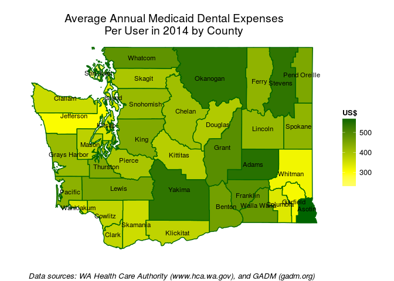

```r
# Create a custom theme from theme_classic
theme_bare <- function(...) {
    theme_classic() +
    theme(axis.line=element_blank(),
          axis.text.x=element_blank(),
          axis.text.y=element_blank(),
          axis.ticks=element_blank(),
          axis.title.x=element_blank(),
          axis.title.y=element_blank())
}

# Prepare map data for ggplot
wa <- fortify(wa, region="NAME_2")

# Map Washington State Medicaid dental expenses by county
gmap <- ggplot() + geom_map(data=expenses, aes(map_id=county, fill=FY2014),
                    color="darkgreen", map=wa) +
    expand_limits(x=wa$long, y=wa$lat) + theme_bare() +
    geom_text(data=cnames, aes(long, lat, label = subregion), size=3) +
    labs(title = "Average Annual Medicaid Dental Expenses\nPer User in 2014 by County") +
    scale_fill_gradient2(space="Lab", high="darkgreen", mid="yellow",
                         low="white", midpoint=300, name="US$")

# Create source attribution string
data.src <- paste0(collapse = ' ', c('Data sources:',
                                     'WA Health Care Authority (www.hca.wa.gov),',
                                     'and GADM (gadm.org)'))

# Layout map with source attribution string at bottom of plot area
gmap <- arrangeGrob(gmap, sub = textGrob(data.src, x=0, hjust=-.1, vjust=0.1,
                                 gp = gpar(fontface="italic", fontsize=10)))
gmap
```